# Bayesian Stats Midterm Jericho McLeod

**Problem 1:** A security screening system photographs people entering a facility, matches them to a database of terrorist suspects, and alerts security to stop an individual for further scrutiny if a match is found. The system has a miss probability of 12% and a false alarm probability of 4%, where a miss is defined as failing to issue an alert for a person in the database, and a false alarm is defined as issuing an alert for a person who is not in the database. Assume that true positives and true negatives cost nothing, and the cost of a miss is 150 times the cost of a false alarm. Let p be the prior probability that a person is in the database. Plot the expected loss of three policies: (1) stop everyone for questioning; (2) stop no one for questioning; and (3) stop someone for questioning if an alert is issued. For what range of p is each policy optimal? Comment on your answer.

| Condition | flagged | not flagged |
| --- | --- | --- |
| terrorist | 0.88 | 0.12 |
| citizen | 0.04 | 0.96 |

| Condition | flagged | not flagged |
| --- | --- | --- |
| terrorist | 0 | 150 |
| citizen | 1 | 0 |

cost of terrorist_not_flagged = 150  
cost of citizen_flagged = 1  
P = probability of terrorist

```r
p_vals <- seq(0,100,1)/100      # represents terrorists
flag_none  <- 150*p_vals        # no cost to citizens
flag_all <- 1*(1-p_vals)        # no costs attributed to terrorists
follow_test <- ((1-p_vals)*1*0.04)+(p_vals*150*0.12)

plot(seq(0,1,0.01),flag_none,
     type="l",
     col="blue",
     main="Utility of Screening",
     xlab="Probability Terrorist",
     ylab="Expected Cost",
     xlim=c(0,.08),
     ylim=c(0,1))
lines(seq(0,1,0.01),flag_all,col='green')
```

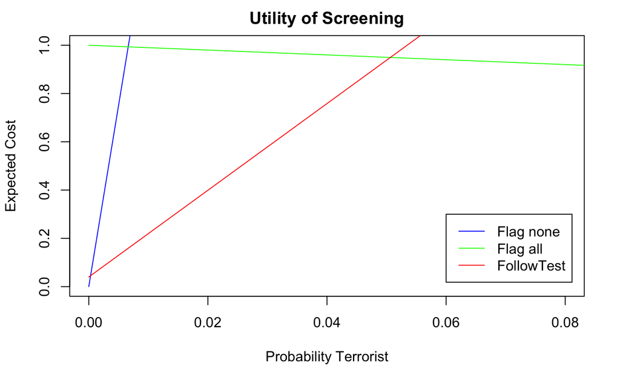

```r
lines(seq(0,1,0.01),follow_test,col="red")
legend(0.06,0.30,c("Flag none","Flag all","FollowTest"),col=c("blue","green","red"),lty=c(1,1,1))
```

These are notably small probabilities, and this relates directly to the fact that the cost of a miss is 150 times that of incorrectly flagging someone who is not in the DB of potential terrorists. Additionally, there are no costs for correct classifications, simplifying the plots somewhat.

**Problem 2:** Historically, one in every 50 fourth-graders at an elementary school fails to reach minimum threshold on a state-mandated reading exam. The school is planning a study to evaluate a new reading curriculum. A school administrator assesses a 55% chance that the new curriculum would reduce the failure rate for the exam. That is, there is a 55% chance that if the new curriculum were implemented, fewer than 1 in 50 students would fail the exam. Suppose the administrator also assesses a 45% chance that the failure rate would be cut in half and a 30% chance that the fail rate is improved by a factor of 10. That is, there is a 45% chance that fewer than 1 in 100 students would fail the exam, and a 30% chance that fewer than 2 in 1000 students would fail the exam under the new curriculum. The administrator also assesses a 35% chance that the failure rate would more than double, or at least 4% of the students would fail the exam. If you were to use a Beta distribution to fit these judgments, what parameters would you use? Do you think it provides a good fit? Justify your answer.

Current Failure Rate: 2% New rates: 55% Chance < 2% 45% Chance < 1% 30% Chance < 0.2% 35% Chance > 4%

```r
require(rriskDistributions)
```

# incomplete

**Problem 3:** A shape recognition system classifies objects as round, rectangular, or irregular. It correctly classifies round objects 80% of the time, rectangular objects 85% of the time, and irregular objects 70% of the time. Incorrectly classified objects are equally likely to be classified as either of the two incorrect object types. Assume in a given environment that 15% of the objects are round, 25% of the objects are rectangular, and 60% of the objects are irregularly shaped. Find the joint distribution of object shapes and classification results. If the system reports that an object is rectangular, what is the posterior probability that the object has each of the three shapes given the system report?

P(correct | round) = 0.80 P(correct | rect) = 0.85 P(correct | irreg) = 0.70

P(round) = 0.15 P(rect) = 0.25 p(irreg) = 0.60

Defining this problem as a vector [round, rectangle, irregular], the form of the joint distribution is a matrix comparing actual shape to classification results, also called a confusion matrix.

| Confusion Matrix | Class: Round | Class: Rect | Class: Irreg |
| --- | --- | --- | --- |
| **Actual: Round** | 0.80 | 0.10 | 0.10 |
| **Actual: Rect** | 0.075 | 0.85 | 0.075 |
| **Actual: Irreg** | 0.15 | 0.15 | 0.70 |

```r
prob_round <- 0.1/(0.1+0.85+0.15)
prob_rect <- 0.85/(0.1+0.85+0.15)
prob_irreg <- 0.15/(0.1+0.85+0.15)

print(prob_round)
```

```
[1] 0.09090909
```

```r
print(prob_rect)
```

```
[1] 0.7727273
```

```r
print(prob_irreg)
```

```
[1] 0.1363636
```

**Problem 4:** A drug for treating depression is undergoing clinical trials. A total of 120 patients were enrolled in a randomized, double-blind, placebo-controlled study. Half of the patients were randomly selected to receive the drug; the remaining patients were given a placebo. Questionnaires were administered at the start of the study and 30 days after treatment began. One of the questions on the post-study questionnaire asked whether patients experienced improvement in their mood since the start of the study. The table below shows responses to this question.

|  | No Improvement | Improvement | Total |
| --- | --- | --- | --- |
| Treatment (Y1) | 18 | 42 | 60 |
| Placebo (Y2) | 26 | 34 | 60 |
| Total | 44 | 76 | 120 |

Let Y1 and Y2 be the number of patients in the treatment and placebo groups who experienced improvement. Assume Y1 and Y2 are independent random variables with Binomial(60, $\theta_i$) distributions, for i=1,2. Assume $\theta_1$ and $\theta_2$ are independent with a Beta distribution with shape parameters 1⁄2 and 1⁄2 (this is the Jeffreys prior distribution). Find the joint posterior distribution for $\theta_1$ and $\theta_2$. Name the distribution type and its hyperparameters. Plot the posterior density functions for $\theta_1$ and $\theta_2$ on the same axes. Comment on your results.

Treatments: 60 Treatment Successes: 42 Placebos: 60 Placebo Successes: 34

```r
c_int2
```

```
[1] 0.4406064 0.6864658
```

**Problem 5:** Generate 5000 random pairs ($\theta_{1i},\theta_{2i}$), i=1, …, 5000 from the joint posterior distribution for ($\theta_1$, $\theta_2$). Use this random sample to estimate the posterior probability that the rate of improvement is higher for treatment than for placebo. Does your analysis support the hypothesis that the drug alleviates symptoms of depression? Explain clearly your process for generating the sample. Discuss your analysis and results.

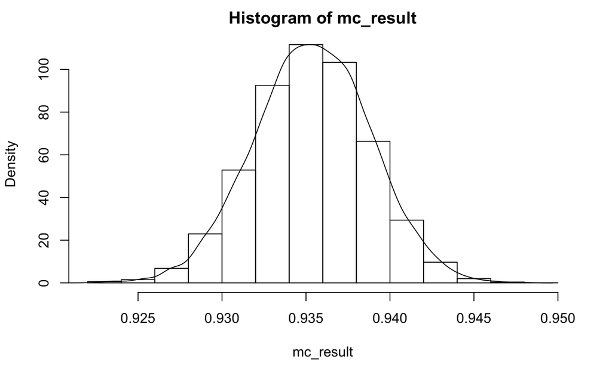

```r
iters  <- seq(0,1,length=10000)
mc_result <- c()
for (i in iters){
  lambda1 <- rbeta(sample_size,shape1=treatment_posterior_shape,shape2=treatment_posterior_scale)
  lambda2 <- rbeta(sample_size,shape1=placebo_posterior_shape,shape2=placebo_posterior_scale)
  Difference  <-  lambda1-lambda2
  probTreatBetter <- sum(Difference>0)/length(Difference)
  mc_result  <- c(mc_result,probTreatBetter)
}

#plotting the histogram  of results
hist_data  <- hist(mc_result,prob=TRUE)
lines(density(mc_result))

#Fitting normal distribution
#This can also be done analytically  by just taking
#the mean and standard distribution
fit_params  <-fitdistr(mc_result,'normal')
print(fit_params)
```

```
       mean            sd
  9.353864e-01   3.456803e-03
 (3.456803e-05) (2.444329e-05)
```

```r
#  Values I got running this:
#       mean            sd
#  9.354622e-01   3.492441e-03

range <- seq(.91,.96,length=100)
normal <-dnorm(range,mean=9.354622e-01,sd=3.492441e-03  )
plot(range,normal,type="l",col='blue',xlab='Probability Treatment > Placebo',ylab='Density')
lines(hist_data$mids,hist_data$density,col='red')
```

[output not shown]